# Fast Bayesian mortality-model screen with R-INLA

Blocked prediction, severe-event behaviour, and repeated-DHW history

Published

August 26, 2026

## Decision summary

R-INLA is fast enough to be useful as a **screening and model-development engine**. The 56 blocked fits completed in 4.5 minutes, with a median of 5.2 seconds per two-component fit. This makes repeated ecological hypothesis tests practical before committing to the longer BRMS fits.

The new paper-motivated history is not a universal replacement for the legacy history variables. It improves manta-tow prediction under both blocked schemes, including 2024, and modestly improves MMP when a whole event is omitted. It worsens LTMP prediction and slightly worsens reef-blocked MMP prediction. Pooled reef-blocked RMSE is effectively unchanged. The appropriate next move is therefore to keep both history definitions as competing candidates and use INLA to screen the expanded stressor model; only the best stable specification should then receive the formal BRMS fit.

Most importantly, neither history formulation resolves severe-event underprediction. Across reef-blocked predictions, mortality observations at or above 50% are underpredicted by about 26 percentage points on average. This is larger than the difference between the history formulations and points back to missing event modifiers, susceptible community composition, and/or the response curve rather than inference speed.

## What was fitted

Each programme was fitted separately using a hurdle-style approximation:

1. Bernoulli model for any mortality versus zero mortality.
2. Beta model for mortality magnitude conditional on mortality being positive.
3. Expected mortality = probability of occurrence x conditional magnitude.

Both components include independent reef, event-year, and region effects. Fixed effects use weakly regularising Gaussian priors; random-effect standard deviations use penalised-complexity priors. All imputation and standardisation are learned inside each analysis fold.

This is close to the ecological decomposition in the formal BRMS model, but it is not an exact replacement for BRMS zero-inflated and zero-one-inflated beta likelihoods. In particular, the two exact MMP values of one are adjusted into the open beta interval in the conditional component. The INLA fit is consequently a fast ranking tool, not the final uncertainty product.

The compact shared predictor set contains current DHW, thresholded DHW terms, pre-event total *Acropora*, pre-event coral cover, ten-year heat load and novelty, low-water-clarity exposure, and cloud cover. The comparison changes only thermal history:

| Candidate | Thermal-history terms |
| --- | --- |
| Legacy history | Historical mean DHW above 6 and years since DHW exceeded 6 |
| Event count + recovery interval | Number of >6-DHW events since 2016, capped years since the last event, and a no-prior-event flag |

Both candidates include interactions of current DHW with composition and thermal history. Freshwater, cyclone, COTS, wind, and upwelling candidates are not yet in the validation rows used here and are therefore not silently imputed into this test.

## Blocked predictive performance

Out-of-sample metrics. Bias is prediction minus observation.

| Programme | History | Validation | n | RMSE | MAE | Predictive R2 | Bias | Occurrence Brier | Severe bias |
| --- | --- | --- | --- | --- | --- | --- | --- | --- | --- |
| LTMP | Event count + recovery interval | Leave one event out | 199 | 0.160 | 0.106 | 0.082 | 0.028 | 0.229 | -0.177 |
| LTMP | Legacy history | Leave one event out | 199 | 0.152 | 0.104 | 0.171 | 0.026 | 0.229 | -0.189 |
| MMP | Event count + recovery interval | Leave one event out | 90 | 0.221 | 0.149 | 0.091 | -0.047 | 0.292 | -0.440 |
| MMP | Legacy history | Leave one event out | 90 | 0.225 | 0.154 | 0.061 | -0.017 | 0.334 | -0.409 |
| Manta tow | Event count + recovery interval | Leave one event out | 248 | 0.147 | 0.110 | 0.085 | -0.007 | 0.257 | -0.390 |
| Manta tow | Legacy history | Leave one event out | 248 | 0.155 | 0.119 | -0.012 | -0.002 | 0.257 | -0.391 |
| LTMP | Event count + recovery interval | Reef-blocked 5-fold | 199 | 0.132 | 0.083 | 0.372 | 0.009 | 0.208 | -0.226 |
| LTMP | Legacy history | Reef-blocked 5-fold | 199 | 0.125 | 0.079 | 0.435 | 0.008 | 0.202 | -0.215 |
| MMP | Event count + recovery interval | Reef-blocked 5-fold | 90 | 0.212 | 0.155 | 0.167 | 0.015 | 0.193 | -0.272 |
| MMP | Legacy history | Reef-blocked 5-fold | 90 | 0.209 | 0.151 | 0.187 | 0.011 | 0.195 | -0.289 |
| Manta tow | Event count + recovery interval | Reef-blocked 5-fold | 248 | 0.118 | 0.084 | 0.412 | 0.001 | 0.171 | -0.297 |
| Manta tow | Legacy history | Reef-blocked 5-fold | 248 | 0.123 | 0.089 | 0.358 | 0.001 | 0.177 | -0.299 |

Pooled programme observations; programmes are not reweighted.

| History | Validation | n | RMSE | MAE | Predictive R2 | Bias | Severe bias |
| --- | --- | --- | --- | --- | --- | --- | --- |
| Event count + recovery interval | Leave one event out | 537 | 0.166 | 0.115 | 0.120 | -0.001 | -0.330 |
| Event count + recovery interval | Reef-blocked 5-fold | 537 | 0.143 | 0.096 | 0.351 | 0.006 | -0.260 |
| Legacy history | Leave one event out | 537 | 0.168 | 0.119 | 0.107 | 0.006 | -0.322 |
| Legacy history | Reef-blocked 5-fold | 537 | 0.142 | 0.096 | 0.359 | 0.006 | -0.263 |

The pooled result should not choose the final model because it gives the largest programme the most weight. Its value here is to show scale: changing the history definition moves RMSE far less than the residual error at high mortality.

## The 2024 event

Reef-blocked performance within 2024.

| Programme | History | n | RMSE | MAE | Predictive R2 | Bias | Severe n | Severe bias |
| --- | --- | --- | --- | --- | --- | --- | --- | --- |
| LTMP | Legacy history | 75 | 0.115 | 0.089 | 0.455 | 0.018 | 4 | -0.072 |
| LTMP | Event count + recovery interval | 75 | 0.132 | 0.096 | 0.288 | 0.023 | 4 | -0.066 |
| Manta tow | Legacy history | 89 | 0.168 | 0.138 | 0.113 | -0.008 | 6 | -0.301 |
| Manta tow | Event count + recovery interval | 89 | 0.159 | 0.129 | 0.208 | -0.007 | 6 | -0.297 |
| MMP | Legacy history | 54 | 0.249 | 0.183 | 0.161 | -0.011 | 13 | -0.289 |
| MMP | Event count + recovery interval | 54 | 0.255 | 0.192 | 0.119 | 0.000 | 13 | -0.272 |

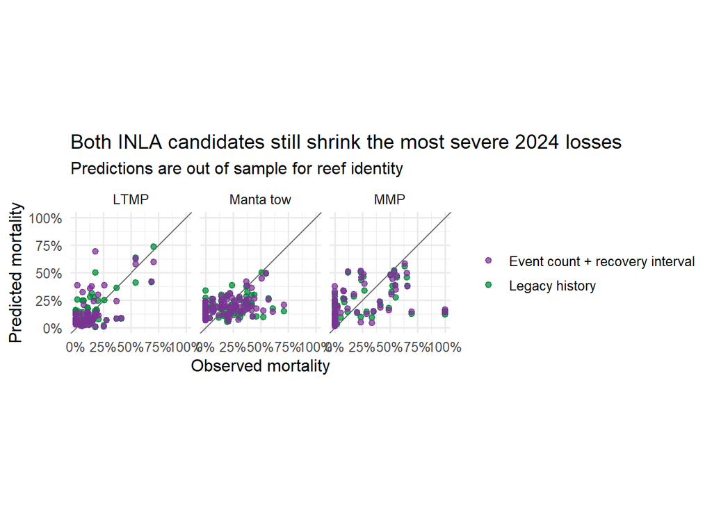

Largest absolute 2024 reef-blocked residuals for the new history candidate.

| Programme | ReefID | ReefName | Observed | Predicted | Observed - predicted |
| --- | --- | --- | --- | --- | --- |
| MMP | 16-006 | Snapper Reef (16-006) | 100.0% | 13.7% | 86.3% |
| MMP | 16-006 | Snapper Reef (16-006) | 100.0% | 16.6% | 83.4% |
| MMP | 16-006 | Snapper Reef (16-006) | 69.4% | 14.4% | 55.1% |
| LTMP | 23-081 | Fairfax Islands Reef (23-081) | 17.6% | 69.5% | -51.9% |
| Manta tow | 14-126 | Linnet Reef (14-126) | 71.5% | 20.5% | 50.9% |
| Manta tow | 16-015 | Mackay Reef (16-015) | 61.3% | 14.5% | 46.7% |
| MMP | 22-009 | Barren Island Reef (22-009) | 11.8% | 51.1% | -39.2% |
| MMP | 17-009a | Tobias Spit (17-009a) | 0.0% | 37.6% | -37.6% |
| Manta tow | 14-118 | Eyrie Reef (14-118) | 52.6% | 15.4% | 37.2% |
| LTMP | 19-207 | Hyde Reef (19-207) | 1.6% | 38.5% | -36.9% |
| MMP | 23-010 | Middle (Ba-la-ba) Island Reef (23-010) | 48.8% | 15.8% | 33.0% |
| MMP | 16-054a | Fitzroy Island Reef (No 1) (16-054a) | 0.0% | 32.8% | -32.8% |
| LTMP | 14-126 | Linnet Reef (14-126) | 41.4% | 8.7% | 32.7% |
| Manta tow | 16-057 | Hastings Reef (16-057) | 42.9% | 10.2% | 32.7% |
| Manta tow | 23-048 | Broomfield Reef (23-048) | 57.1% | 25.5% | 31.7% |

The familiar manta-tow misses remain visible at Linnet, Mackay, and Eyrie. The largest MMP misses are repeated observations at Snapper Island. Conversely, Fairfax, Hyde, Barren, Tobias, and Fitzroy include large overpredictions. These are useful ecological audit targets: a single steeper DHW curve cannot fix both directions without modifiers that separate exacerbated from ameliorated exposure.

## Full-data fit criteria

Summed occurrence and positive-magnitude criteria from full-data fits.

| Programme | History | WAIC | Delta WAIC | DIC | Delta DIC |
| --- | --- | --- | --- | --- | --- |
| LTMP | Legacy history | 93.4 | 0.0 | 86.1 | 0.0 |
| LTMP | Event count + recovery interval | 100.7 | 7.3 | 95.1 | 9.0 |
| MMP | Event count + recovery interval | 37.3 | 0.0 | 37.0 | 0.0 |
| MMP | Legacy history | 39.2 | 1.9 | 38.6 | 1.6 |
| Manta tow | Event count + recovery interval | 114.5 | 0.0 | 113.5 | 0.0 |
| Manta tow | Legacy history | 129.4 | 14.9 | 127.0 | 13.5 |

WAIC favours the new history for manta tow and MMP, but the LTMP result favours legacy history. These criteria describe full-data fit and cannot override the blocked prediction results. They are most useful when they agree with the out-of-sample comparison.

## Posterior history effects

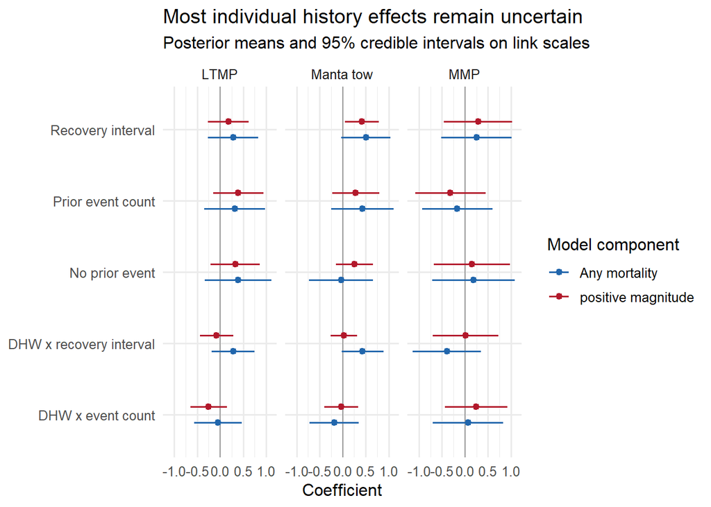

The most consistent ecological signal is in manta tow: a longer recovery interval is positively associated with the magnitude of mortality, compatible with rebuilding susceptible communities between major events. Most other history intervals overlap zero, especially in MMP. These terms should therefore be judged as a grouped predictive hypothesis, not selected one coefficient at a time.

## Recommended next implementation step

Use INLA for one controlled expansion of this screen:

1. Join the operationally available stressor fields to these exact validation rows: coloured-water anomaly or rainfall/runoff proxy, cyclone 4-m wave hours, COTS pressure, wind/doldrum exposure, and an upwelling or cooling proxy.
2. Compare a shared core, core plus exacerbating stressors, core plus ameliorating stressors, and the combined model under the same blocked folds.
3. Retain both history definitions during that comparison; do not choose a programme-wide winner from pooled RMSE alone.
4. Examine severe-loss sensitivity, calibration, and named reef-year residuals alongside RMSE, MAE, predictive R2, occurrence Brier score, WAIC, and DIC.
5. Promote the smallest set of candidates that materially improves blocked prediction—especially severe 2024 mortality—to formal BRMS fitting. BRMS then supplies the exact boundary-aware likelihood, posterior predictive checks, and final uncertainty intervals.

This preserves the speed advantage of INLA without treating its approximate two-part likelihood as the final operational model.